# R勉強会

Maruyama Shohei

# プロジェクト・ファイルの作成

- 左上の「Create a project」でプロジェクトを作成できる。
- プロジェクトを作成しておくと、以下のようなメリットがある。
  - Gitでの管理がかんたんになる。
  - デフォルトフォルダがプロジェクトのフォルダになる
  - 他のプロジェクトと環境を独立させることができる
- 左上のボタンからRスクリプトのファイルを作成する。
  - 後々のレポート作成のことを考えると「R markdown」でファイルを作成するのがおすすめ。

# コードの作成・実行

- `Alt + Control + I`でチャンクを作成する。
  - Rのコードはこのチャンクの中に書いていく
- `Control + Enter`でカーソル行のコードを実行
- `Control + Shift + Enter`でチャンク内のコードをすべて実行する。

# ライブラリの読み込み

- ライブラリのインストールは`install.packages("[ライブラリ名]")`で行う。
- インストールしたライブラリはコード内で読み込む必要がある。
  - ライブラリの読み込みは`library`で行う。

```r
#ライブラリの読み込み----
library(tidyverse)
library(magrittr)
library(corrr)
library(GGally)
library(esquisse)
```

# データの読み込み

- データの読み込みは`read_csv()`で行う
- `Shift-JIS`のファイルを読み込む際は、オプションで`locale=locale(encoding="CP932")`を指定

```r
#データの読み込み
data <-
  "output.csv" %>%
  read_csv(locale=locale(encoding="CP932"))

# フラグの追加
data2 <-
  data %>%
    filter(
    floor_plan %in% c('1DK','1K','1LDK')
  ) %>%
  mutate(
    flag_dokuritsu_senmendai = if_else(details %>% str_detect("洗面化粧台"),1,0),
    flag_oidaki              = if_else(details %>% str_detect("追焚"),1,0)
  )
```

# データのサマリを確認

```r
data2 %>% summary
```

```
#        X1             name               url                 rent
#  Min.   :   2.0   Length:872         Length:872         Min.   : 28000
#  1st Qu.: 344.8   Class :character   Class :character   1st Qu.: 79000
#  Median : 703.5   Mode  :character   Mode  :character   Median : 98000
#  Mean   : 702.4                                         Mean   :101177
#  3rd Qu.:1044.2                                         3rd Qu.:119000
#  Max.   :1415.0                                         Max.   :200000
#
#      admin          deposit         key_money       shozaichi
#  Min.   :    0   Min.   :     0   Min.   :     0   Length:872
#  1st Qu.: 2000   1st Qu.: 65000   1st Qu.: 65750   Class :character
#  Median : 5000   Median : 92000   Median : 92000   Mode  :character
#  Mean   : 5300   Mean   : 91270   Mean   : 89637
#  3rd Qu.: 8000   3rd Qu.:118000   3rd Qu.:118000
#  Max.   :20000   Max.   :400000   Max.   :358000
#
#   ekitoho_1          ekitoho_2          ekitoho_3
#  Length:872         Length:872         Length:872
#  Class :character   Class :character   Class :character
#  Mode  :character   Mode  :character   Mode  :character
#
#
#
#
#   floor_plan        floor_plan_detail       area            age
#  Length:872         Length:872         Min.   :10.00   Min.   : 0.00
#  Class :character   Class :character   1st Qu.:21.64   1st Qu.: 7.00
#  Mode  :character   Mode  :character   Median :26.57   Median :15.00
#                                        Mean   :28.28   Mean   :19.02
#                                        3rd Qu.:33.71   3rd Qu.:30.00
#                                        Max.   :63.08   Max.   :64.00
#
#      floor            muki              kouzou               lat
#  Min.   :-1.000   Length:872         Length:872         Min.   :35.69
#  1st Qu.: 2.000   Class :character   Class :character   1st Qu.:35.69
#  Median : 3.000   Mode  :character   Mode  :character   Median :35.70
#  Mean   : 3.523                                         Mean   :35.70
#  3rd Qu.: 5.000                                         3rd Qu.:35.70
#  Max.   :23.000                                         Max.   :35.71
#  NA's   :2
```

[output cut: 25 more lines]

```
#  Min.   :0.0000   Min.   :0.0000   Min.   :0.0000
#  1st Qu.:0.0000   1st Qu.:0.0000   1st Qu.:0.0000
#  Median :1.0000   Median :1.0000   Median :0.0000
#  Mean   :0.5206   Mean   :0.5378   Mean   :0.3532
#  3rd Qu.:1.0000   3rd Qu.:1.0000   3rd Qu.:1.0000
#  Max.   :1.0000   Max.   :1.0000   Max.   :1.0000
#
#   flag_oidaki
#  Min.   :0.0000
#  1st Qu.:0.0000
#  Median :0.0000
#  Mean   :0.3486
#  3rd Qu.:1.0000
#  Max.   :1.0000
#
```

```r
data2 %>% head
```

```
# # A tibble: 6 x 34
#      X1 name  url     rent admin deposit key_money shozaichi ekitoho_1
#   <dbl> <chr> <chr>  <dbl> <dbl>   <dbl>     <dbl> <chr>     <chr>
# 1     2 メゾン淀… http… 124000  5000  124000    124000 東京都中野区中央… 東京メトロ丸ノ内…
# 2     4 アビオン… http… 131000     0  131000    131000 東京都中野区中央… 都営大江戸線/中…
# 3     5 アビオン… http… 131000     0  131000    131000 東京都中野区中央… 東京メトロ丸ノ内…
# 4     8 アルファ… http… 129000     0  129000    129000 東京都中野区中央… 東京メトロ丸ノ内…
# 5    11 Ｔ.Pa… http… 115000  4000  115000    172500 東京都中野区東中… ＪＲ総武線/東中…
# 6    12 T.Pa… http… 118000  4000  118000    177000 東京都中野区東中… ＪＲ中央線/東中…
# # … with 25 more variables: ekitoho_2 <chr>, ekitoho_3 <chr>,
# #   floor_plan <chr>, floor_plan_detail <chr>, area <dbl>, age <dbl>,
# #   floor <dbl>, muki <chr>, kouzou <chr>, lat <dbl>, lng <dbl>,
# #   details <chr>, flag_teikishakuya <dbl>, rent_total <dbl>,
# #   dist_nakanosakaue <dbl>, flag_not_unitbath <dbl>, flag_kado <dbl>,
# #   flag_yokushitsu_kansou <dbl>, flag_autolock <dbl>, flag_takuhai <dbl>,
# #   flag_3_konro <dbl>, flag_2_konro <dbl>, flag_onsui <dbl>,
# #   flag_dokuritsu_senmendai <dbl>, flag_oidaki <dbl>
```

```r
# data2 %>% View
```

## 各列の意味について

| 列名 | 意味 |
| --- | --- |
| id | id |
| name | 賃貸名 |
| url | 賃貸情報のURL |
| rent | 賃料 |
| admin | 管理費/共益費 |
| rent_total | 賃料+管理費+共益費 |
| deposit | 敷金 |
| key_money | 礼金 |
| shozaichi | 住所 |
| ekitoho_1~3 | 駅から徒歩何分か |
| floor_plan | 間取り |
| floor_plan_detail | 間取り詳細 |
| area | 床面積 |
| age | 築年数 |
| floor | 階数 |
| muki | 向き |
| kouzou | 構造 |
| lat,lon | 経度・緯度 |
| dist_nakanosakaue | 中野坂上までの距離 |
| details | 物件詳細 |
| flag_teikishakuya | 定期借家なら1 |
| flag_not_unitbath | ユニットバスでないなら1 |
| flag_kado | 角部屋なら1 |
| flag_yokushitsu_kanso | 浴室乾燥付きなら1 |
| flag_autolock | オートロックなら1 |
| flag_takuhai | 宅配ボックス付きなら1 |
| flag_3_konro | 3口コンロ付きなら1 |
| flag_2_konro | 2口コンロ付きなら1 |
| flag_onsui | ウォッシュレット付きなら1 |
| flag_dokuritsu_senmendai | 独立洗面台付きなら1 |
| flag_oidaki | 追焚機能付きなら1 |

```r
data2 %>% head
```

```
# # A tibble: 6 x 34
#      X1 name  url     rent admin deposit key_money shozaichi ekitoho_1
#   <dbl> <chr> <chr>  <dbl> <dbl>   <dbl>     <dbl> <chr>     <chr>
# 1     2 メゾン淀… http… 124000  5000  124000    124000 東京都中野区中央… 東京メトロ丸ノ内…
# 2     4 アビオン… http… 131000     0  131000    131000 東京都中野区中央… 都営大江戸線/中…
# 3     5 アビオン… http… 131000     0  131000    131000 東京都中野区中央… 東京メトロ丸ノ内…
# 4     8 アルファ… http… 129000     0  129000    129000 東京都中野区中央… 東京メトロ丸ノ内…
# 5    11 Ｔ.Pa… http… 115000  4000  115000    172500 東京都中野区東中… ＪＲ総武線/東中…
# 6    12 T.Pa… http… 118000  4000  118000    177000 東京都中野区東中… ＪＲ中央線/東中…
# # … with 25 more variables: ekitoho_2 <chr>, ekitoho_3 <chr>,
# #   floor_plan <chr>, floor_plan_detail <chr>, area <dbl>, age <dbl>,
# #   floor <dbl>, muki <chr>, kouzou <chr>, lat <dbl>, lng <dbl>,
# #   details <chr>, flag_teikishakuya <dbl>, rent_total <dbl>,
# #   dist_nakanosakaue <dbl>, flag_not_unitbath <dbl>, flag_kado <dbl>,
# #   flag_yokushitsu_kansou <dbl>, flag_autolock <dbl>, flag_takuhai <dbl>,
# #   flag_3_konro <dbl>, flag_2_konro <dbl>, flag_onsui <dbl>,
# #   flag_dokuritsu_senmendai <dbl>, flag_oidaki <dbl>
```

# 家賃のヒストグラムを書いてみる

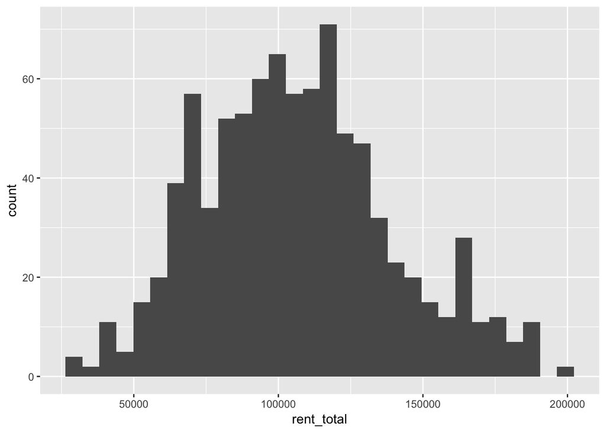

```r
data2 %>%
  ggplot(
    aes(
      x = rent_total
    )
  ) +
  geom_histogram()
```

# 部屋の向き別の家賃

```r
data2$muki %>% table
```

```
# .
#    -   西   東   南 南西 南東   北 北西 北東
#   85  133  194  264   50   43   66   11   26
```

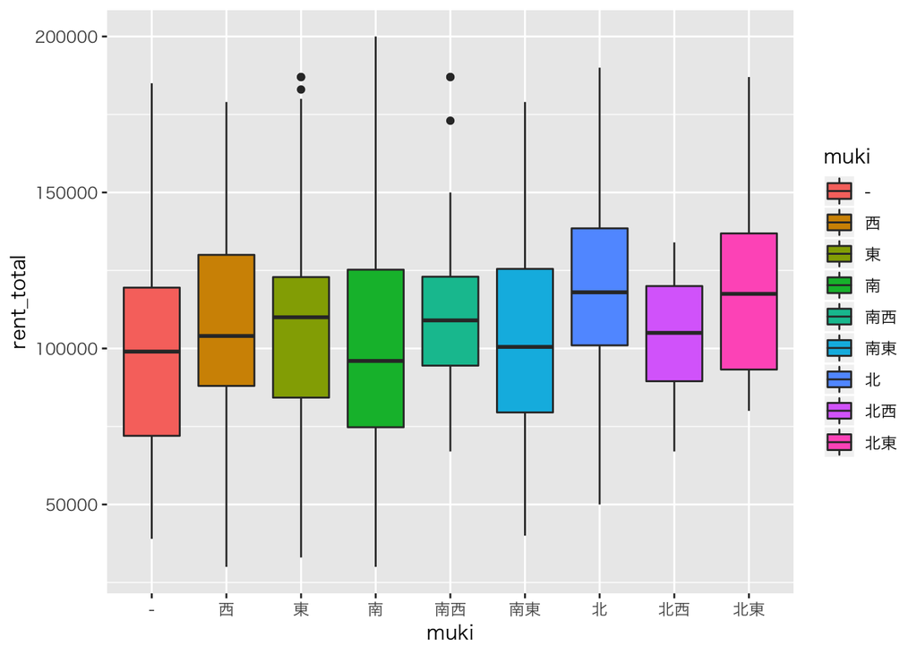

```r
data2 %>%
  ggplot(
    aes(
      x = muki,
      y = rent_total,
      fill   = muki
    )
  ) +
  geom_boxplot() +
  theme_gray(base_family = "HiraKakuPro-W3")
```

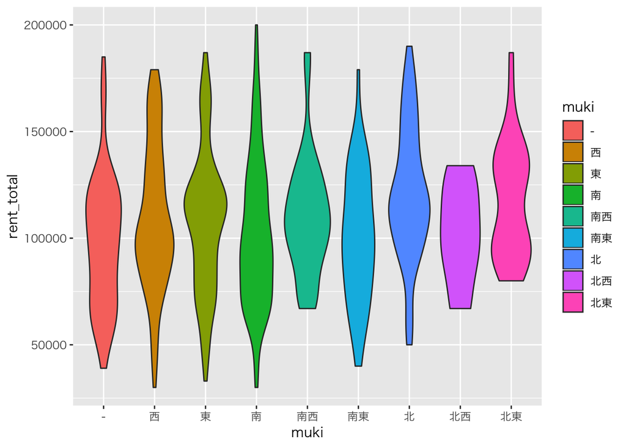

```r
data2 %>%
  ggplot(
    aes(
      x = muki,
      y = rent_total,
      fill   = muki
    )
  ) +
  geom_violin() +
  theme_gray(base_family = "HiraKakuPro-W3")
```